# Lesson 150 · Q3 checkpoint: defend a full reproduction

Teacher solution · PROVIDED / TODO / CHECK / EXIT. Tier B full relational task. Three live functions separate selection, aggregation and verdict. Default audit is distinct from the explicit full GPU reproduction.

```python
# @colab-bootstrap — portable CPU mechanism and evidence audit by default.
import os,sys,subprocess
os.environ.update(OMP_NUM_THREADS='1',OPENBLAS_NUM_THREADS='1',MKL_NUM_THREADS='1')
if 'google.colab' in sys.modules:
    subprocess.check_call([sys.executable,'-m','pip','install','-q','pytorch-frame==0.2.3','torch-geometric==2.6.1','relbench==1.1.0','sentence-transformers==3.3.1'])
from pathlib import Path
import base64,hashlib,io,json,zlib,math,statistics
import pandas as pd
from IPython.display import display
RUN_FULL_REPRODUCTION=False
VALIDATE_ONE=False;PREPARED_ROOT=None
```

```python
"""RelGNN source-aligned architecture with explicit composite arithmetic.

MIT upstream cffdb8b54627e92c7dd112c1243dde739c90d35b; see sources/l141/LICENSE.
Selected variant: sum aggregation, no edge attributes, no simplified_MP.
PyG owns parameter containers; the load-bearing forward arithmetic is visible below.
"""
# %% Imports and live learner operators
import math
from collections import defaultdict
from typing import Any, Dict, List, Optional
import numpy as np
import torch
import torch_frame
from torch import Tensor
from torch.nn import Embedding, ModuleDict
from torch_frame.data.stats import StatType
from torch_frame.nn.models import ResNet
from torch_geometric.nn import LayerNorm, PositionalEncoding, MLP
from torch_geometric.nn.dense.linear import Linear
from torch_geometric.nn.conv import TransformerConv, SAGEConv
from torch_geometric.typing import EdgeType, NodeType
from torch_geometric.data import HeteroData
from torch_geometric.nn.module_dict import ModuleDict as RouteModuleDict
```

```python
# PROVIDED: audited compatibility and first-minimum helpers
def verify_numeric_layout(columns, moments, checkpoint_mean, checkpoint_std):
    """Check ordered numerical feature semantics against saved encoder buffers."""
    expected=np.asarray([moments[c] for c in columns],dtype=float)
    mean=np.asarray(checkpoint_mean,dtype=float);std=np.asarray(checkpoint_std,dtype=float)
    if expected.shape!=(len(columns),2) or mean.shape!=(len(columns),) or std.shape!=mean.shape:
        raise ValueError('Numerical column count differs')
    if not np.isfinite(expected).all() or not np.isfinite(mean).all() or not np.isfinite(std).all():
        raise ValueError('Nonfinite normalization evidence')
    if not np.allclose(expected[:,0],mean,rtol=1e-6,atol=1e-6) or not np.allclose(expected[:,1],std,rtol=1e-6,atol=1e-6):
        raise ValueError('Ordered feature moments differ')
    return True
def first_validation_min(history):
    """First minimum on a finite, contiguous validation history; never test scores."""
    if not history or [x['epoch'] for x in history]!=list(range(1,len(history)+1)):
        raise ValueError('History must be complete and ordered from epoch1')
    values=np.asarray([x['val_mae'] for x in history],dtype=float)
    if not np.isfinite(values).all():raise ValueError('Nonfinite validation metric')
    return int(np.argmin(values))+1
```

From a weakness catalog to a defensible reproduction report

**Reading route.** Freeze the claim → trace the model → select using validation → separate the evidence gates → defend the report.

**Quick prerequisite reminder**

A checkpoint stores a model’s learned state. A replay evaluates saved weights; a fresh fit trains new weights. A validation set chooses a configuration or checkpoint, while test measures the frozen choice. A gate is a separate requirement supported by its own evidence. SOTA means state of the art: a claim about competitive performance under comparable evaluation conditions.

## 1 · Defend a claim, not just a score

**Your checkpoint:** defend one complete RelGNN reproduction, then explain exactly what it establishes. A good score, a runnable notebook and a convincing report are different achievements.

[Lesson 143](https://avistian.github.io/relational/lessons/0143-relgnn-reproduction.html) exposed the distance between loading published weights and recovering a training procedure. [Lesson 145](https://avistian.github.io/relational/lessons/0145-relational-graph-transformer.html) showed why an available implementation can still fail temporal and budget requirements. [Lesson 149](https://avistian.github.io/relational/lessons/0149-weakest-relbench-tasks.html) made counter-evidence part of the thesis. Now combine those skills into a report another researcher can audit.

**Read first:** [RelGNN v2 §5.2 and Table 2](https://arxiv.org/html/2502.06784v2#S5.T2), then the [pinned released implementation](https://github.com/snap-stanford/RelGNN/tree/cffdb8b54627e92c7dd112c1243dde739c90d35b). The paper reports **3.798 test MAE** on `rel-f1/driver-position`. Our attempt preserves the released architecture, documents unreleased training choices, and evaluates two primary tracks of five fresh fits each, plus three validation-only search fits. The released-checkpoint replay is a separate evaluation.

**One tangible deliverable:** an evidence-backed reproduction report with a manifest, complete seed table, uncertainty statement and written defense. The core lesson explains the gates; the lab supplies the computation and report scaffold. Passing author checks does not pass your checkpoint.

## 2 · Freeze the claim before running

> **In plain terms.** Decide what counts as success before you can see which story the results favor. Otherwise a disappointing training run can quietly become a successful checkpoint replay, or a historical score can quietly become “current SOTA.”

**MAE**, mean absolute error, is the average absolute distance between predicted and actual finishing position. Lower is better. A **seed** initializes one stochastic run. A **reference reconstruction** is a complete training procedure whose missing historical choices are explicitly frozen by the course. It is not a claim that those choices reproduce the authors' private run state.

We distinguish four measured tracks:

| Track | Runs | Purpose | May choose the tuned configuration? |
| --- | --- | --- | --- |
| Released checkpoint | One compatibility replay | Test whether released weights and reconstructed feature layout work together | No |
| Reference reconstruction | Five seeds, 0–4 | Reattempt the frozen L143 training recipe | No |
| Validation search | Three learning rates, seed 100 | Choose one declared course configuration | Yes, from validation only |
| Selected course procedure | Five fresh seeds, 10–14 | Measure the chosen configuration across runs | No |

The notebook's extra validation seed 1000 is another execution check. It does not join either primary mean. Search fits are not primary evaluation seeds. Every fit uses all 7,453 training queries and ten complete epochs; validation has 499 queries and test has 760.

**Historical score gate:** the five-seed mean must be within a frozen **±0.20 MAE** of 3.798 to receive `CLOSE`. This is a descriptive reproduction tolerance. It is not a confidence interval, a significance test, or a definition of current near-SOTA. A better score far outside the band would need explanation too: closeness and predictive quality are different questions.

**Closeness and quality can rank results differently.** Keep protocol execution valid and compare hypothetical complete-track means with the fixed paper target 3.798:

| Mean MAE | Distance from paper | Score gate |
| --- | --- | --- |
| 3.500 | 0.298 | Outside |
| 3.798 | 0 | Close |
| 3.900 | 0.102 | Close |

The lowest error is outside the closeness band, while a higher error is inside it. The gate measures resemblance to one published scalar; it is not the optimization objective. An unexpectedly good result deserves checks of population, inputs, selection and metrics before it becomes evidence of a method improvement. These are hypothetical means, separate from the measured tracks below.

**Try it after the example.** Keep mean 3.798 but fail the protocol audit. What should the paper-score gate say?

**Check your reasoning**

INCOMPARABLE. Exact numerical agreement does not repair an invalid comparison; the protocol gate takes precedence in the actual verdict function.

**Current competitive-standing gate:** require a separate comparable benchmark audit. The [RelBench leaderboard](https://star-project.stanford.edu/relbench/leaderboard/) displays normalized MAE, not the historical raw MAE. The [RelArena protocol](https://star-project.stanford.edu/relarena/) changes data-state, tuning and final refit rules. The [archived audit dated 2026-09-30](https://avistian.github.io/relational/labs/evidence/l150/current-context.json) retrieved the leaderboard data rather than trusting its static “No entries yet” fallback. Treat it as a dated protocol comparison; recheck the current board before making a new competitive claim. A numerical comparison without reconciling metric normalization and protocol would be invalid. This checkpoint does not establish current SOTA or near-SOTA.

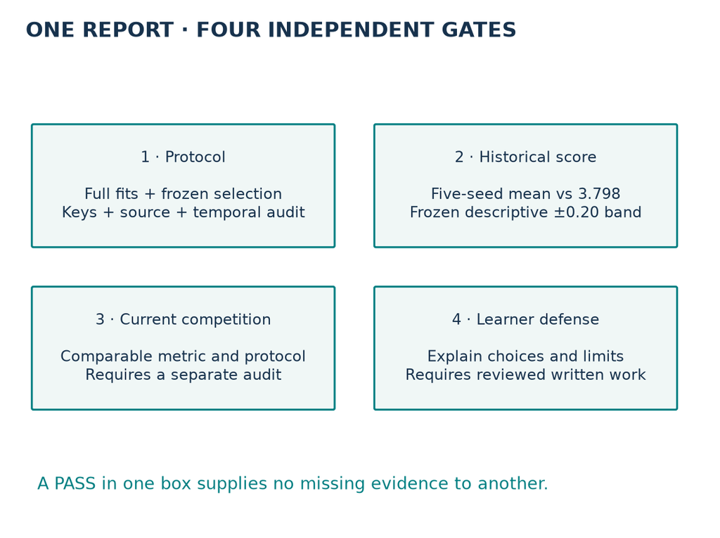

Four independent questions: complete protocol, historical score closeness, current comparable performance and learner defense. Scroll horizontally on narrow screens.

## 3 · Trace the model and its information boundary

A query is `(driver_id, cutoff)`. The target is mean finishing position in the next 60 days, conditional on the driver participating. Future participation defines which labels exist; this is not an all-driver forecast with a label for every possible query.

The database becomes a graph with one node per row and primary–foreign-key edges. A row encoder converts each table's numerical, categorical, time and text attributes into a 128-channel representation. Relative-time features locate history relative to the owning query. An **atomic route** connects a source to a destination directly or through a bridge/fact row. RelGNN fuses source and intermediate information, attends over relevant messages, aggregates routes and predicts a scalar driver position.

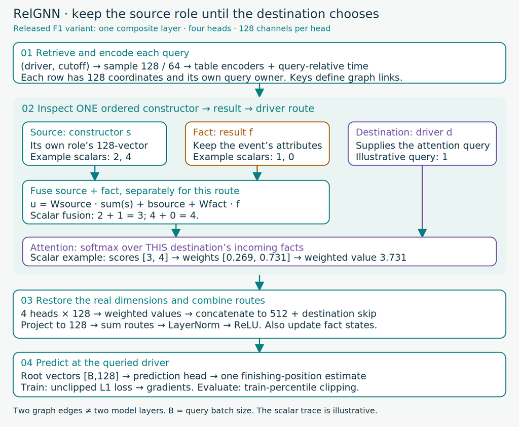

RelGNN end to end: query-owned temporal sampling, row and time encoders, atomic routes, destination attention and scalar driver prediction. Scroll horizontally on narrow screens.

**Read the diagram with one route.** A constructor is the team responsible for a car. Its vector and a historical result row’s vector combine before the driver weights incoming messages. In the diagram’s scalar example, source values `[2,4]` and fact values `[1,0]` produce messages `[3,4]`. A driver query of 1 gives weights approximately `[0.269,0.731]` and a weighted value of `3.731`. These illustrate the operation; they are not measured F1 embeddings. In the real model, each of four attention heads produces 128 coordinates; their 512-coordinate concatenation is projected back to 128. Different routes then combine before the driver prediction. [Revisit the derivation in Lesson 141](https://avistian.github.io/relational/lessons/0141-composite-message-passing.html).

The selected model has one composite layer, four attention heads and sum aggregation. Two graph sampling hops, 128 then 64 neighbors, expose the composite routes. Batch size is 512; training uses Adam and absolute-error loss. The reference learning rate is 0.005. Evaluation clips predictions to training-label percentiles 2 and 98. The first strict minimum-validation checkpoint is saved; later ties do not replace it. Sampling at final evaluation can yield a validation score different from the selection-time score.

**Information ownership:** every sampled dated node must be no later than its particular query's cutoff. A batch-wide maximum cutoff would let an earlier query borrow a later query's history. The raw-label audit separately reconstructs all 8,712 targets and query identities. Equal row counts alone would not detect reordered or mismatched queries.

**Feature semantics:** the released checkpoint expects `qualifying.position` as numerical, but fresh type inference makes it categorical. The compatibility replay reconstructs that column layout using ordered checkpoint means and standard deviations. Other fresh-training inputs remain unchanged. Matching moments support compatibility; they do not uniquely recover the authors' historical cache.

> **Scope check.** This historical reconstruction fits preprocessing on the released test-cutoff database snapshot, not strictly on training rows. Event-time sampling does not recover missing feature-arrival or mutation histories. Source parity means our implementation agrees with the released computation; it does not establish that all gradients are healthy or that the historical experiment is identified.

```python
# PROVIDED — inspect this model stage.
def get_atomic_routes(edge_type_list):

    src_to_tuples = defaultdict(list)
    for src, rel, dst in edge_type_list:
        if rel.startswith('f2p'):
            if src == dst:
                src = src + '--' + rel
            src_to_tuples[src].append((src, rel, dst))

    atomic_routes_list = []
    get_rev_edge = lambda edge: (edge[2], 'rev_' + edge[1], edge[0])
    for src, tuples in src_to_tuples.items():
        if '--' in src:
            src = src.split('--')[0]
        if len(tuples) == 1:
            _, rel, dst = tuples[0]
            edge = (src, rel, dst)
            atomic_routes_list.append(('dim-dim',) + edge)
            atomic_routes_list.append(('dim-dim',) + get_rev_edge(edge))
        else:
            for _, rel_q, dst_q in tuples:
                for _, rel_v, dst_v in tuples:
                    if rel_q != rel_v:
                        edge_q = (src, rel_q, dst_q)
                        edge_v = (src, rel_v, dst_v)
                        atomic_routes_list.append(('dim-fact-dim',) + edge_q + get_rev_edge(edge_v))

    return atomic_routes_list

def destination_softmax(scores, destination, num_destinations):
    """Normalize each head over incoming messages for the same destination."""
    index = destination[:, None].expand_as(scores)
    maxima = scores.new_full((num_destinations, scores.shape[1]), -torch.inf)
    maxima.scatter_reduce_(0, index, scores.detach(), reduce='amax', include_self=True)
    weights = (scores - maxima[destination]).exp()
    totals = scores.new_zeros((num_destinations, scores.shape[1]))
    totals.index_add_(0, destination, weights)
    return weights / (totals[destination] + 1e-16)

def keyed_mae(query_keys, targets, prediction_keys, predictions):
    """A repeated entity at another cutoff is a distinct forecast."""
    q = [tuple(k) for k in query_keys]; p = [tuple(k) for k in prediction_keys]
    y = np.asarray(targets, dtype=float); pred = np.asarray(predictions, dtype=float)
    if not q or len(set(q)) != len(q) or len(set(p)) != len(p) or set(q) != set(p):
        raise ValueError('Require equal unique query-key populations')
    if y.shape != (len(q),) or pred.shape != (len(p),) or not np.isfinite(y).all() or not np.isfinite(pred).all():
        raise ValueError('Require finite one-dimensional targets and predictions')
    lookup = dict(zip(p, pred))
    return float(np.mean(np.abs(y - np.array([lookup[k] for k in q]))))
```

```python
# PROVIDED — inspect this model stage.
# %% Composite operator: role-specific fact representation then attention
class RelGNNConv(TransformerConv):
    def __init__(self, attn_type, in_channels, out_channels, heads, aggr,
                 simplified_MP=False, bias=True, **kwargs):
        super().__init__(in_channels, out_channels, heads, bias=bias, **kwargs)
        if aggr != 'sum' or simplified_MP:
            raise ValueError('This audited lesson implements the selected full sum variant')
        self.attn_type = attn_type
        if attn_type == 'dim-fact-dim':
            self.aggr_conv = SAGEConv(in_channels, out_channels, aggr=aggr)
        self.simplified_MP = simplified_MP
        self.final_proj = Linear(heads * out_channels, out_channels, bias=bias)
        self.final_proj.reset_parameters()

    def attend(self, source, destination, edges):
        # [nodes, heads, channels/head-output]; here each head outputs 128 channels.
        h, c = self.heads, self.out_channels
        q = self.lin_query(destination).view(-1, h, c)
        k = self.lin_key(source).view(-1, h, c)
        v = self.lin_value(source).view(-1, h, c)
        src, dst = edges
        scores = (q[dst] * k[src]).sum(-1) / math.sqrt(c)
        alpha = destination_softmax(scores, dst, len(destination))
        messages = v[src] * alpha[:, :, None]
        aggregate = messages.new_zeros((len(destination), h, c))
        aggregate.index_add_(0, dst, messages)
        # Source defaults: concatenate heads, add a destination skip, then project.
        joined = aggregate.reshape(len(destination), h*c) + self.lin_skip(destination)
        return self.final_proj(joined)

    def forward(self, x, edge_index, edge_attr=None, return_attention_weights=None):
        if edge_attr is not None or return_attention_weights is not None:
            raise ValueError('Selected experiment does not use edge attributes or attention return flags')
        if self.attn_type == 'dim-dim':
            return self.attend(x[0], x[1], edge_index)
        edge_attn, edge_aggr = edge_index
        source, fact, destination = x
        src, dst = edge_aggr
        gathered = source.new_zeros((len(fact), source.shape[1]))
        gathered.index_add_(0, dst, source[src])
        # SAGE sum + transformed fact root; unique to this ordered FK pair.
        intermediate = self.aggr_conv.lin_l(gathered) + self.aggr_conv.lin_r(fact)
        return self.attend(intermediate, destination, edge_attn), intermediate
```

```python
# PROVIDED — inspect this model stage.
# %% Route dispatch and route-output sums
def group(xs: List[Tensor], aggr: Optional[str]) -> Optional[Tensor]:
    if len(xs) == 0:
        return None
    elif aggr is None:
        return torch.stack(xs, dim=1)
    elif len(xs) == 1:
        return xs[0]
    elif aggr == "cat":
        return torch.cat(xs, dim=-1)
    else:
        out = torch.stack(xs, dim=0)
        out = getattr(torch, aggr)(out, dim=0)
        out = out[0] if isinstance(out, tuple) else out
        return out
class RelGNN_HeteroConv(torch.nn.Module):

    def __init__(self, convs, aggr: Optional[str]='sum', simplified_MP: Optional[bool]=False):
        super().__init__()
        self.convs = RouteModuleDict(convs)
        self.aggr = aggr
        self.simplified_MP = simplified_MP

    def reset_parameters(self):
        for conv in self.convs.values():
            conv.reset_parameters()

    def forward(self, x_dict, edge_index_dict) -> Dict[NodeType, Tensor]:
        out_dict: Dict[str, List[Tensor]] = {}

        def update(out_dict, dst, out):
            if dst not in out_dict:
                out_dict[dst] = [out]
            else:
                out_dict[dst].append(out)
        for edge_type_info, conv in self.convs.items():
            attn_type = edge_type_info[0]
            if attn_type == 'dim-dim':
                src, rel, dst = edge_type_info[1:]
                x = (x_dict.get(src, None), x_dict.get(dst, None))
                edge_index = edge_index_dict[src, rel, dst]
                out = conv(x, edge_index)
                if self.simplified_MP and out is None:
                    continue
                update(out_dict, dst, out)
            elif attn_type == 'dim-fact-dim':
                edge_attn, edge_aggr = (edge_type_info[1:4], edge_type_info[4:])
                src_attn, _, dst = edge_attn
                src_aggr = edge_aggr[0]
                x = (x_dict[src_aggr], x_dict[src_attn], x_dict[dst])
                edge_index = (edge_index_dict[edge_attn], edge_index_dict[edge_aggr])
                out = conv(x, edge_index)
                if self.simplified_MP and out is None:
                    continue
                out_dst, out_src_attn = out
                update(out_dict, dst, out_dst)
                update(out_dict, src_attn, out_src_attn)
        for key, value in out_dict.items():
            out_dict[key] = group(value, self.aggr)
        if self.simplified_MP:
            for key, value in x_dict.items():
                if key not in out_dict:
                    out_dict[key] = value
        return out_dict

    def __repr__(self) -> str:
        return f'{self.__class__.__name__}(num_relations={len(self.convs)})'
```

```python
# PROVIDED — inspect this model stage.
# %% Table encoders and query-relative time
class HeteroEncoder(torch.nn.Module):
    r"""HeteroEncoder based on PyTorch Frame.

    Args:
        channels (int): The output channels for each node type.
        node_to_col_names_dict (Dict[NodeType, Dict[torch_frame.stype, List[str]]]):
            A dictionary mapping from node type to column names dictionary
            compatible to PyTorch Frame.
        torch_frame_model_cls: Model class for PyTorch Frame. The class object
            takes :class:`TensorFrame` object as input and outputs
            :obj:`channels`-dimensional embeddings. Default to
            :class:`torch_frame.nn.ResNet`.
        torch_frame_model_kwargs (Dict[str, Any]): Keyword arguments for
            :class:`torch_frame_model_cls` class. Default keyword argument is
            set specific for :class:`torch_frame.nn.ResNet`. Expect it to
            be changed for different :class:`torch_frame_model_cls`.
        default_stype_encoder_cls_kwargs (Dict[torch_frame.stype, Any]):
            A dictionary mapping from :obj:`torch_frame.stype` object into a
            tuple specifying :class:`torch_frame.nn.StypeEncoder` class and its
            keyword arguments :obj:`kwargs`.
    """

    def __init__(
        self,
        channels: int,
        node_to_col_names_dict: Dict[NodeType, Dict[torch_frame.stype, List[str]]],
        node_to_col_stats: Dict[NodeType, Dict[str, Dict[StatType, Any]]],
        torch_frame_model_cls=ResNet,
        torch_frame_model_kwargs: Dict[str, Any] = {
            "channels": 128,
            "num_layers": 4,
        },
        default_stype_encoder_cls_kwargs: Dict[torch_frame.stype, Any] = {
            torch_frame.categorical: (torch_frame.nn.EmbeddingEncoder, {}),
            torch_frame.numerical: (torch_frame.nn.LinearEncoder, {}),
            torch_frame.multicategorical: (
                torch_frame.nn.MultiCategoricalEmbeddingEncoder,
                {},
            ),
            torch_frame.embedding: (torch_frame.nn.LinearEmbeddingEncoder, {}),
            torch_frame.timestamp: (torch_frame.nn.TimestampEncoder, {}),
        },
    ):
        super().__init__()

        self.encoders = torch.nn.ModuleDict()

        for node_type in node_to_col_names_dict.keys():
            stype_encoder_dict = {
                stype: default_stype_encoder_cls_kwargs[stype][0](
                    **default_stype_encoder_cls_kwargs[stype][1]
                )
                for stype in node_to_col_names_dict[node_type].keys()
            }
            torch_frame_model = torch_frame_model_cls(
                **torch_frame_model_kwargs,
                out_channels=channels,
                col_stats=node_to_col_stats[node_type],
                col_names_dict=node_to_col_names_dict[node_type],
                stype_encoder_dict=stype_encoder_dict,
            )
            self.encoders[node_type] = torch_frame_model

    def reset_parameters(self):
        for encoder in self.encoders.values():
            encoder.reset_parameters()

    def forward(
        self,
        tf_dict: Dict[NodeType, torch_frame.TensorFrame],
    ) -> Dict[NodeType, Tensor]:
        x_dict = {
            node_type: self.encoders[node_type](tf) for node_type, tf in tf_dict.items()
        }
        return x_dict
class HeteroTemporalEncoder(torch.nn.Module):
    def __init__(self, node_types: List[NodeType], channels: int):
        super().__init__()

        self.encoder_dict = torch.nn.ModuleDict(
            {node_type: PositionalEncoding(channels) for node_type in node_types}
        )
        self.lin_dict = torch.nn.ModuleDict(
            {node_type: torch.nn.Linear(channels, channels) for node_type in node_types}
        )

    def reset_parameters(self):
        for encoder in self.encoder_dict.values():
            encoder.reset_parameters()
        for lin in self.lin_dict.values():
            lin.reset_parameters()

    def forward(
        self,
        seed_time: Tensor,
        time_dict: Dict[NodeType, Tensor],
        batch_dict: Dict[NodeType, Tensor],
    ) -> Dict[NodeType, Tensor]:
        out_dict: Dict[NodeType, Tensor] = {}

        for node_type, time in time_dict.items():
            rel_time = seed_time[batch_dict[node_type]] - time
            rel_time = rel_time / (60 * 60 * 24)  # Convert seconds to days.

            x = self.encoder_dict[node_type](rel_time)
            x = self.lin_dict[node_type](x)
            out_dict[node_type] = x

        return out_dict
```

```python
# PROVIDED — inspect this model stage.
# %% Composite stack and node normalization
class RelGNN(torch.nn.Module):
    def __init__(
        self,
        node_types: List[NodeType],
        edge_types: List[EdgeType],
        channels: int,
        aggr: str = "sum",
        num_model_layers: int = 2,
        num_heads: int = 1,
        simplified_MP=False,
    ):
        super().__init__()

        self.convs = torch.nn.ModuleList()
        for _ in range(num_model_layers):
            conv = RelGNN_HeteroConv(
                {
                    edge_type: RelGNNConv(edge_type[0], (channels, channels), channels, num_heads, aggr=aggr, simplified_MP=simplified_MP)
                    for edge_type in edge_types
                },
                aggr=aggr,
                simplified_MP=simplified_MP,
            )
            self.convs.append(conv)

        self.norms = torch.nn.ModuleList()
        for _ in range(num_model_layers):
            norm_dict = torch.nn.ModuleDict()
            for node_type in node_types:
                norm_dict[node_type] = LayerNorm(channels, mode="node")
            self.norms.append(norm_dict)

    def reset_parameters(self):
        for conv in self.convs:
            conv.reset_parameters()
        for norm_dict in self.norms:
            for norm in norm_dict.values():
                norm.reset_parameters()

    def forward(
        self,
        x_dict: Dict[NodeType, Tensor],
        edge_index_dict: Dict[NodeType, Tensor],
        num_sampled_nodes_dict: Optional[Dict[NodeType, List[int]]] = None,
        num_sampled_edges_dict: Optional[Dict[EdgeType, List[int]]] = None,
    ) -> Dict[NodeType, Tensor]:
        for _, (conv, norm_dict) in enumerate(zip(self.convs, self.norms)):
            x_dict = conv(x_dict, edge_index_dict)
            x_dict = {key: norm_dict[key](x) for key, x in x_dict.items()}
            x_dict = {key: x.relu() for key, x in x_dict.items()}

        return x_dict
```

```python
# PROVIDED — inspect this model stage.
# %% Whole-model forward pass: table -> time -> routes -> head
class RelGNN_Model(torch.nn.Module):

    def __init__(
        self,
        data: HeteroData,
        col_stats_dict: Dict[str, Dict[str, Dict[StatType, Any]]],
        num_model_layers: int,
        channels: int,
        out_channels: int,
        aggr: str,
        norm: str,
        # List of node types to add shallow embeddings to input
        shallow_list: List[NodeType] = [],
        # ID awareness
        id_awareness: bool = False,
        atomic_routes=None,
        num_heads=None,
        simplified_MP=False,
    ):
        super().__init__()

        self.encoder = HeteroEncoder(
            channels=channels,
            node_to_col_names_dict={
                node_type: data[node_type].tf.col_names_dict
                for node_type in data.node_types
            },
            node_to_col_stats=col_stats_dict,
        )
        self.temporal_encoder = HeteroTemporalEncoder(
            node_types=[
                node_type for node_type in data.node_types if "time" in data[node_type]
            ],
            channels=channels,
        )
        self.gnn = RelGNN(
            node_types=data.node_types,
            edge_types=atomic_routes,
            channels=channels,
            aggr=aggr,
            num_model_layers=num_model_layers,
            num_heads=num_heads,
            simplified_MP=simplified_MP,
        )
        self.head = MLP(
            channels,
            out_channels=out_channels,
            norm=norm,
            num_layers=1,
        )
        self.embedding_dict = ModuleDict(
            {
                node: Embedding(data.num_nodes_dict[node], channels)
                for node in shallow_list
            }
        )

        self.id_awareness_emb = None
        if id_awareness:
            self.id_awareness_emb = torch.nn.Embedding(1, channels)
        self.reset_parameters()

    def reset_parameters(self):
        self.encoder.reset_parameters()
        self.temporal_encoder.reset_parameters()
        self.gnn.reset_parameters()
        self.head.reset_parameters()
        for embedding in self.embedding_dict.values():
            torch.nn.init.normal_(embedding.weight, std=0.1)
        if self.id_awareness_emb is not None:
            self.id_awareness_emb.reset_parameters()

    def forward(
        self,
        batch: HeteroData,
        entity_table: NodeType,
    ) -> Tensor:
        seed_time = batch[entity_table].seed_time
        x_dict = self.encoder(batch.tf_dict)

        rel_time_dict = self.temporal_encoder(
            seed_time, batch.time_dict, batch.batch_dict
        )

        for node_type, rel_time in rel_time_dict.items():
            x_dict[node_type] = x_dict[node_type] + rel_time

        for node_type, embedding in self.embedding_dict.items():
            x_dict[node_type] = x_dict[node_type] + embedding(batch[node_type].n_id)

        x_dict = self.gnn(
            x_dict,
            batch.edge_index_dict,
        )

        return self.head(x_dict[entity_table][: seed_time.size(0)])

    def forward_dst_readout(
        self,
        batch: HeteroData,
        entity_table: NodeType,
        dst_table: NodeType,
    ) -> Tensor:
        if self.id_awareness_emb is None:
            raise RuntimeError(
                "id_awareness must be set True to use forward_dst_readout"
            )
        seed_time = batch[entity_table].seed_time
        x_dict = self.encoder(batch.tf_dict)
        # Add ID-awareness to the root node
        x_dict[entity_table][: seed_time.size(0)] += self.id_awareness_emb.weight

        rel_time_dict = self.temporal_encoder(
            seed_time, batch.time_dict, batch.batch_dict
        )

        for node_type, rel_time in rel_time_dict.items():
            x_dict[node_type] = x_dict[node_type] + rel_time

        for node_type, embedding in self.embedding_dict.items():
            x_dict[node_type] = x_dict[node_type] + embedding(batch[node_type].n_id)

        x_dict = self.gnn(
            x_dict,
            batch.edge_index_dict,
        )

        return self.head(x_dict[dst_table])
```

```python
# PROVIDED/CHECK: complete model fixture and source differential
"""Synthetic whole-model forward/backward; no paper-result claim."""
import pandas as pd
import torch
from torch_frame import stype
from torch_frame.data import Dataset
from torch_geometric.data import HeteroData

def neural_fixture(Model,route_builder):
    torch.set_num_threads(1);torch.manual_seed(141);data=HeteroData();stats={}
    for name,values in [('drivers',[1.,2.,3.,4.]),('results',[3.,5.,9.,10.]),('constructors',[2.,7.,11.,16.])]:
        frame=Dataset(pd.DataFrame({'x':values}),col_to_stype={'x':stype.numerical}).materialize()
        data[name].tf=frame.tensor_frame;stats[name]=frame.col_stats;data[name].num_nodes=4
        data[name].batch=torch.tensor([0,1,0,1]);data[name].n_id=torch.arange(4)
    data['drivers'].seed_time=torch.tensor([864000,1728000]);data['results'].time=torch.tensor([777600,1555200,691200,1468800])
    for dst,fk in [('drivers','driverId'),('constructors','constructorId')]:
        edge=torch.tensor([[0,1,2,3],[0,1,0,1]])
        data['results','f2p_'+fk,dst].edge_index=edge;data[dst,'rev_f2p_'+fk,'results'].edge_index=edge.flip(0)
    model=Model(data,stats,1,128,1,'sum','batch_norm',atomic_routes=route_builder(data.edge_types),num_heads=4)
    model.train();pred=model(data,'drivers').view(-1);assert pred.shape==(2,)
    loss=torch.nn.functional.l1_loss(pred,torch.tensor([3.,5.]));loss.backward();report={}
    for name,part in [('encoder',model.encoder),('time',model.temporal_encoder),('gnn',model.gnn),('head',model.head)]:
        grads=[p.grad for p in part.parameters() if p.grad is not None]
        assert grads and all(torch.isfinite(g).all() for g in grads)
        norm=sum(float(g.square().sum()) for g in grads)**.5;assert norm>0
        report[name]=norm
    return dict(status='PASS',prediction=pred.detach().tolist(),loss=float(loss.detach()),gradient_norms=report,scope='finite synthetic fixture; real missing-value gradients audited separately')

"""Original source differential check, including outputs and all active gradients."""
import contextlib,sys,types
from pathlib import Path
import torch

@contextlib.contextmanager
def original_modules(source_root):
    names=['atomic_routes','relgnn_conv','relgnn_hetero_conv','relgnn_nn','relgnn_model']
    old={n:sys.modules.get(n) for n in names}
    try:
        for name in names:
            m=types.ModuleType(name);sys.modules[name]=m
            exec(compile((Path(source_root)/('examples__'+name+'.py')).read_text(),name,'exec'),m.__dict__)
        yield sys.modules['relgnn_model'].RelGNN_Model,sys.modules['relgnn_conv'].RelGNNConv
    finally:
        for n,m in old.items():
            if m is None:sys.modules.pop(n,None)
            else:sys.modules[n]=m

def check(source_root):
    torch.manual_seed(141);torch.set_num_threads(1)
    errors=[];gradients=0
    with original_modules(source_root) as (_,Original):
        for mode in ['dim-dim','dim-fact-dim']:
            for empty in [False,True]:
                a=RelGNNConv(mode,(4,4),4,2,aggr='sum').double()
                b=Original(mode,(4,4),4,2,aggr='sum').double();b.load_state_dict(a.state_dict())
                x=[torch.randn(n,4,dtype=torch.float64,requires_grad=True) for n in ([3,2] if mode=='dim-dim' else [3,4,2])]
                y=[v.detach().clone().requires_grad_() for v in x]
                e=torch.tensor([[0,1,2],[0,0,1]]) if not empty else torch.empty((2,0),dtype=torch.long)
                edges=e if mode=='dim-dim' else (e,torch.tensor([[0,1,2],[0,1,2]]))
                oa=a(tuple(x),edges);ob=b(tuple(y),edges)
                aa=(oa,) if mode=='dim-dim' else oa;bb=(ob,) if mode=='dim-dim' else ob
                for u,v in zip(aa,bb):
                    torch.testing.assert_close(u,v,atol=1e-12,rtol=1e-12);errors.append(float((u-v).abs().max().detach()))
                sum(u.square().sum() for u in aa).backward();sum(u.square().sum() for u in bb).backward()
                for (ka,pa),(kb,pb) in zip(a.named_parameters(),b.named_parameters()):
                    assert ka==kb
                    if pa.grad is not None:
                        torch.testing.assert_close(pa.grad,pb.grad,atol=1e-11,rtol=1e-11);gradients+=1
                for u,v in zip(x,y):torch.testing.assert_close(u.grad,v.grad,atol=1e-11,rtol=1e-11)
    return dict(status='PASS',cases=4,parameter_gradient_tensors=gradients,max_output_error=max(errors),dtype='float64',scope='operator outputs/input and parameter gradients; empty attention edges included')

fixture_report=neural_fixture(RelGNN_Model,get_atomic_routes)
parity_report=check(SOURCE_ROOT)
print(fixture_report);print(parity_report)
```

```
{'status': 'PASS', 'prediction': [0.2750357985496521, 0.17854303121566772], 'loss': 3.7732105255126953, 'gradient_norms': {'encoder': 12.472479212084211, 'time': 2.9564404218610196, 'gnn': 15.724884797006611, 'head': 7.647992597504548}, 'scope': 'finite synthetic fixture; real missing-value gradient…
{'status': 'PASS', 'cases': 4, 'parameter_gradient_tensors': 46, 'max_output_error': 0.0, 'dtype': 'float64', 'scope': 'operator outputs/input and parameter gradients; empty attention edges included'}
```

## 4 · Tune without letting test choose

**Learning rate** controls the size of optimizer updates. We search only `{0.001, 0.003, 0.005}`. Each candidate uses seed 100, the same complete data, ten epochs and the same architecture. Its score is its first minimum validation MAE across epochs. The lowest score wins; smaller learning rate breaks exact ties. This search space was approved before these new results.

**Worked example.** If candidate validation minima are 3.20, 3.10 and 3.10, select learning rate 0.003. A test score of 3.0 for the 0.005 candidate would not change that selection. The test score should not even be present in the selection packet. Our search loader raises an error if asked for the test split.

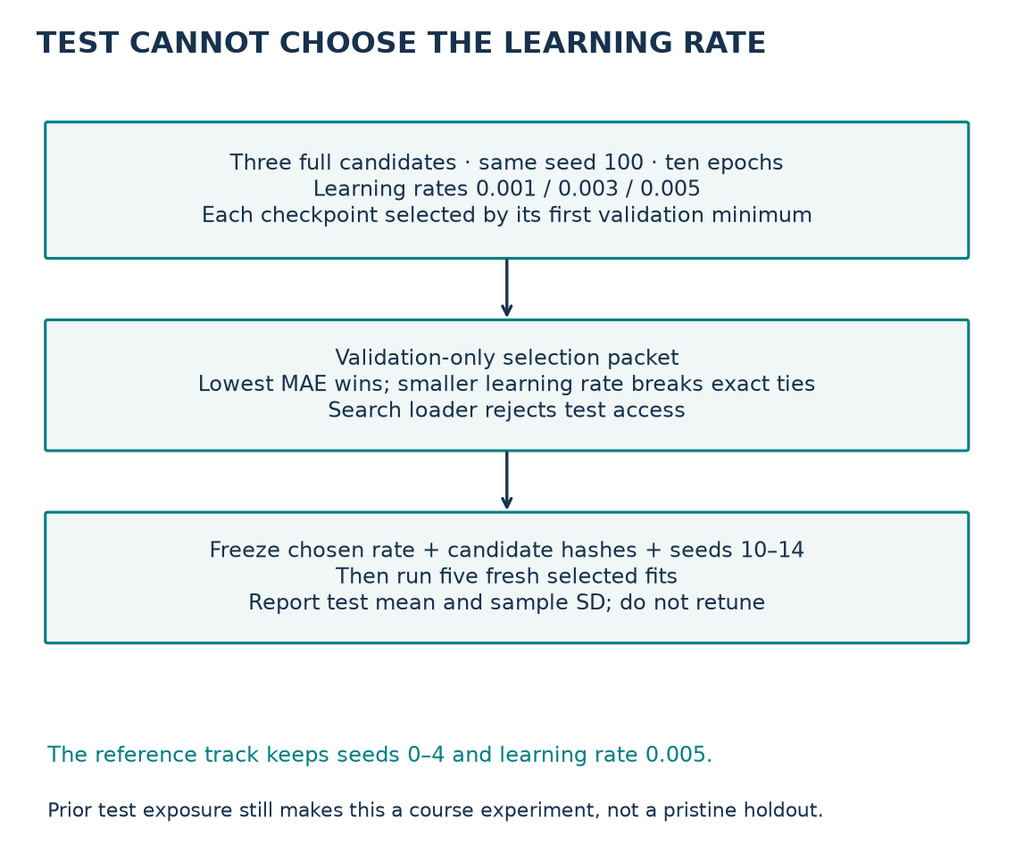

Only validation enters candidate selection. A frozen choice precedes the five fresh selected fits. Scroll horizontally on narrow screens.

A single search seed is a budget choice, not proof of a stable hyperparameter ranking. The five fresh selected seeds measure sensitivity to training randomness after that choice. They do not estimate the uncertainty of running the entire search repeatedly. The reference and selected tracks use different seed sets, so their difference is not a paired-seed intervention estimate.

| Learning rate | First minimum validation MAE |
| --- | --- |
| 0.001 | 3.856391 |
| 0.003 | 2.968465 |
| 0.005 | 3.309320 |

Frozen winner: **0.003**. These are checkpoint-selection scores, not the final resampled validation scores.

A **hash** is a compact fingerprint computed from file contents. Here it identifies the exact result file used in selection. A frozen selection record stores candidate scores, their file hashes, the chosen rate and final seed IDs. The selected-run operator checks those hashes before launch. Changing a result after freezing makes the operator refuse it. This guards record integrity; it does not retroactively erase the author's exposure to this test population in earlier lessons.

```python
# TODO — used by the real evidence audit and full reproduction.
def select_candidate(rows):
    """Exactly three predeclared candidates; first-validation-minimum scores only."""
    if len(rows)!=3 or {r['lr'] for r in rows}!={.001,.003,.005}:
        raise ValueError('Require all three distinct planned learning rates')
    for r in rows:
        if r['split']!='val' or r['seed']!=100 or r['epochs']!=10 or not r['complete']:
            raise ValueError('Incomplete or wrong selection protocol')
        if any('test' in k.lower() for k in r):raise ValueError('Test information in selection packet')
        if not math.isfinite(r['selection_mae']) or r['selection_mae']<0:raise ValueError('Invalid validation score')
    return min(rows,key=lambda r:(r['selection_mae'],r['lr']))['lr']
```

```python
# CHECK — run unchanged.
def rejects(fn):
 try:fn()
 except ValueError:return
 raise AssertionError('Invalid evidence accepted')
def check_select(fn):
 rows=[dict(lr=.005,seed=100,epochs=10,complete=True,split='val',selection_mae=3.1),dict(lr=.001,seed=100,epochs=10,complete=True,split='val',selection_mae=3.1),dict(lr=.003,seed=100,epochs=10,complete=True,split='val',selection_mae=3.2)]
 assert fn(rows)==.001
 rejects(lambda:fn(rows[:-1]))
 rejects(lambda:fn([dict(r,split='test') for r in rows]))
 rejects(lambda:fn([dict(rows[0],complete=False)]+rows[1:]))
 rejects(lambda:fn([dict(rows[0],selection_mae=float('nan'))]+rows[1:]))
 rejects(lambda:fn([dict(rows[0],seed=0)]+rows[1:]))
 rejects(lambda:fn([dict(rows[0],test_mae=1.)]+rows[1:]))
check_select(select_candidate)
print("PASS select_candidate")
```

```
PASS select_candidate
```

## 5 · Read the complete evidence packet

Before revealing the numbers, predict which is strongest evidence of fresh training: matching one released checkpoint, or collecting every planned seed even if its average misses the paper.

Write your prediction before reading the table: which evidence establishes fresh training, and which establishes historical identity?

| Track | Validation MAE | Test MAE | Historical score gate |
| --- | --- | --- | --- |
| Paper Table 2 | — | 3.798 | Published target |
| Checkpoint replay | 2.836661 | 3.737381 | Separate inference lane |
| Reference, five full fits | 3.101280 ± 0.080420 | 4.314567 ± 0.371880 | OUTSIDE_TOLERANCE |
| Selected, five full fits | 3.186087 ± 0.094588 | 4.079708 ± 0.099947 | OUTSIDE_TOLERANCE |

Mean ± sample SD. All **15,346 predictions** across ten primary fits, three validation-only search fits and one replay were independently aligned and rescored. **Protocol: PASS · Historical identity: NOT_ESTABLISHED · Current competitive standing: NOT_ESTABLISHED · Whole paper: NOT_RUN · Learner: PENDING_WRITTEN_DEFENSE.**

**Inspect every primary seed**

| Track | Seed | Test MAE |
| --- | --- | --- |
| reference | 0 | 3.905680 |
| reference | 1 | 3.990684 |
| reference | 2 | 4.297924 |
| reference | 3 | 4.688169 |
| reference | 4 | 4.690378 |
| selected | 10 | 4.016070 |
| selected | 11 | 4.092329 |
| selected | 12 | 3.963810 |
| selected | 13 | 4.227917 |
| selected | 14 | 4.098417 |

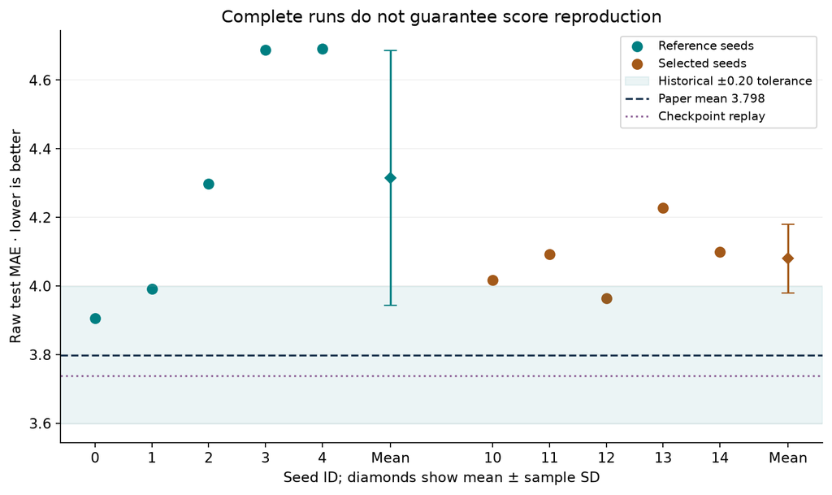

Every primary seed and its track mean with sample SD, separate from published mean and checkpoint replay. Scroll horizontally on narrow screens.

**What the spread means.** We report the mean and sample standard deviation (SD) over exactly five runs per primary track. SD describes run-to-run variability here. It is not a confidence interval for all possible F1 queries, all databases or all future training protocols. Five values are too few to make small differences look settled. No post-test retuning is allowed.

A **gradient** describes how a parameter affects the training loss. Nonfinite gradients contain undefined or infinite values; finite predictions alone cannot establish healthy learning.

**What was independently checked:** all labels from raw future result rows; all primary and search prediction identities; complete epoch populations; first-validation-minimum checkpoint choices; source-model outputs on the same sampled batches; query-specific temporal bounds; and a separate first-batch gradient comparison. The report retains nonfinite-gradient counts rather than silently repairing the release and still calling it the original procedure.

The independent real first-batch audit matched **640 nonfinite gradient entries**, with maximum finite-entry difference **1.2e-07**. This supports source agreement on that batch while exposing a gradient-health limitation; it does not establish healthy training.

**Use a gate vector, not one green badge.** A complete execution can miss its paper-score tolerance. A compatible checkpoint can score well without recovering training. A score can match an old paper while current competitive standing remains unestablished. A fully checked author packet still needs your written defense.

The controls below are illustrative reviewer scenarios, not edits to the measured report. Predict the gate that changes before toggling one input. The measured baseline remains visible.

Illustrative baseline: five complete seeds, mean3.90 → protocol PASS, historical score CLOSE, competitive standing NOT_ESTABLISHED, learner PENDING_WRITTEN_DEFENSE.

```python
# TODO — used by the real evidence audit and full reproduction.
def summarize_track(rows,track,expected_seeds):
    """No checkpoint inference, missing fit, duplicate seed or mixed track allowed."""
    seeds=[r['seed'] for r in rows]
    if len(set(expected_seeds))!=5 or len(seeds)!=5 or set(seeds)!=set(expected_seeds):
        raise ValueError('Require exactly the five planned seeds')
    if track not in ('reference','selected'):raise ValueError('Unknown primary training track')
    for r in rows:
        if r['track']!=track or not r['complete'] or r['epochs']!=10:raise ValueError('Not a complete primary fit')
        if not math.isfinite(r['test_mae']) or r['test_mae']<0:raise ValueError('Invalid test score')
    values=[r['test_mae'] for r in sorted(rows,key=lambda r:r['seed'])]
    return dict(track=track,seeds=sorted(seeds),values=values,mean=statistics.mean(values),sample_sd=statistics.stdev(values))
```

```python
# CHECK — run unchanged.
def rejects(fn):
 try:fn()
 except ValueError:return
 raise AssertionError('Invalid evidence accepted')
def check_summary(fn):
 rows=[dict(seed=i,track='reference',complete=True,epochs=10,test_mae=3.8+i*.01) for i in range(5)]
 r=fn(rows,'reference',list(range(5)));assert abs(r['mean']-3.82)<1e-12 and r['sample_sd']>0
 rejects(lambda:fn(rows[:-1],'reference',list(range(5))))
 rejects(lambda:fn(rows+[rows[0]],'reference',list(range(5))))
 rejects(lambda:fn([dict(rows[0],track='replay')]+rows[1:],'reference',list(range(5))))
 rejects(lambda:fn([dict(rows[0],epochs=1)]+rows[1:],'reference',list(range(5))))
 rejects(lambda:fn([dict(rows[0],test_mae=float('inf'))]+rows[1:],'reference',list(range(5))))
check_summary(summarize_track)
print("PASS summarize_track")
```

```
PASS summarize_track
```

```python
# TODO — used by the real evidence audit and full reproduction.
def checkpoint_verdict(protocol_ok,mean,competitive_audit,defense_passed):
    """Audit/defense booleans must come from independent review, never from the score."""
    if not math.isfinite(mean) or mean<0:raise ValueError('Invalid mean')
    return dict(protocol='PASS' if protocol_ok else 'FAIL',paper_score=('CLOSE' if abs(mean-3.798)<=.20+1e-12 else 'OUTSIDE_TOLERANCE') if protocol_ok else 'INCOMPARABLE',competitive='SUPPORTED_BY_SEPARATE_AUDIT' if competitive_audit and protocol_ok else 'NOT_ESTABLISHED',learner='DEFENDED' if defense_passed else 'PENDING_WRITTEN_DEFENSE')
```

```python
# CHECK — run unchanged.
def rejects(fn):
 try:fn()
 except ValueError:return
 raise AssertionError('Invalid evidence accepted')
def check_verdict(fn):
 r=fn(True,3.9,False,False);assert r['protocol']=='PASS' and r['paper_score']=='CLOSE' and r['competitive']=='NOT_ESTABLISHED' and r['learner']=='PENDING_WRITTEN_DEFENSE'
 r=fn(True,4.1,False,False);assert r['paper_score']=='OUTSIDE_TOLERANCE'
 r=fn(False,3.8,False,False);assert r['protocol']=='FAIL' and r['paper_score']=='INCOMPARABLE'
 r=fn(True,3.798,True,True);assert r['competitive']=='SUPPORTED_BY_SEPARATE_AUDIT' and r['learner']=='DEFENDED'
 rejects(lambda:fn(True,float('nan'),False,False))
check_verdict(checkpoint_verdict)
print("PASS checkpoint_verdict")
```

```
PASS checkpoint_verdict
```

## 6 · Submit the report and defend it

[Student notebook](https://avistian.github.io/relational/labs/0150-q3-reproduction-checkpoint.ipynb) · [Prepared notebook](https://avistian.github.io/relational/labs/html/0150-q3-reproduction-checkpoint.html) · [Reference](https://avistian.github.io/relational/reference/q3-reproduction-checkpoint.html) · [Protocol](https://avistian.github.io/relational/labs/l150-reproduction.md) · [Report template](https://avistian.github.io/relational/labs/l150-report-template.md).

Implement three live functions: validation-only candidate selection, complete-track aggregation, and separate evidence gates. The checks reject partial seed sets, checkpoint substitution, test-bearing selection packets and nonfinite scores. Your functions process the real author results. The full reproduction appendix shows the architecture, preprocessing, compatibility helper and trainer inline; its explicit GPU gate can execute the reference, search and selected tracks in a fresh directory.

### Report structure

1. **Claim and protocol:** exact task, paper version, source/checkpoint/data hashes, model, epochs, optimizer, preprocessing, split, selection and budget.
2. **Complete results:** every reference and selected seed; all three search candidates; checkpoint replay separately; means and sample SD.
3. **Audit and deviations:** key alignment, temporal checks, source parity, gradient health, missing historical details and differing current protocols.
4. **Verdict:** one status per gate. Do not hide a failed score gate behind successful code execution.
5. **Weakness and next experiment:** use L149's counter-evidence. State one change, what stays fixed, a falsifier and a bounded cost. A proposal is not an executed result.

### Checkpoint rubric

| Dimension | 0 · missing | 1 · partial | 2 · defensible |
| --- | --- | --- | --- |
| Reproducible procedure | Recipe absent | Commands without complete identity | Pinned inputs, full runs, executable code |
| Selection and temporal validity | Test leakage or mixed cutoffs | Correct intent, incomplete audit | Frozen selection and query-specific checks |
| Evidence interpretation | Replay, training and SOTA conflated | Some boundaries acknowledged | All tracks and uncertainty separated |
| Counter-evidence | Weakness omitted | Gap reported without falsifier | Concrete limitation and testable next step |
| Written defense | No explanation | Describes outputs only | Explains mechanism, choices and claim limits |

A score of at least 8/10 with no zero is the proposed **report-readiness** threshold, assessed by the teaching agent after you submit. It does not override a failed competitive-performance requirement. The curriculum's SOTA/near-SOTA objective remains open until supported by a comparable evaluation. A failed reproduction can be an excellent report and still be an unmet performance goal.

**EXIT · 250–400 words plus artifacts.** Attach your generated checkpoint report and write the defense. Explain why the selected rate won, whether the reference and course tracks met their historical score gates, why the checkpoint replay cannot substitute for either, and what evidence is still needed for current competitive standing. End with one falsifiable next experiment. Learner status remains **PENDING_WRITTEN_DEFENSE** until reviewed.

Complete the written EXIT and submit it for review.

Ask the teaching agent about any unclear mechanism or evidence boundary. Revisit the candidate-selection and four-gate questions tomorrow and a week later. Carry this report structure into the [Q4 multi-task portfolio](https://avistian.github.io/relational/plan/year-4.md), where success must extend beyond one familiar task.

**Carry this forward.** Take the report structure and Lesson 149’s counter-evidence into [the planned Lesson 151 entity-classification portfolio](https://avistian.github.io/relational/plan/year-4.md). The next challenge changes the task and metric: rebuild the population and evaluation contract before reusing the pipeline. Completing another F1 fit would not answer that transfer question.

```python
# CHECK: live functions evaluate every real author prediction vector.
rows=[];rng=np.random.default_rng(150)
for record in AUTHOR_SUMMARY['records']:
    phase=record['phase'];splits=['val'] if record['track']=='search' else ['val','test']
    for split in splits:
        prefix=phase+'_'+split+'_';keys=list(zip(DATA[prefix+'entity'],DATA[prefix+'time']))
        order=rng.permutation(len(keys))
        score=keyed_mae(keys,DATA[prefix+'target'],[keys[i] for i in order],DATA[prefix+'pred'][order])
        assert abs(score-record[split+'_mae'])<1e-12
        rows.append(dict(lane=phase,split=split,mae=score,queries=len(keys)))
assert select_candidate(AUTHOR_SUMMARY['search']['candidates'])==AUTHOR_SUMMARY['search']['lr']
report_tracks={}
for track,seeds in [('reference',list(range(5))),('selected',list(range(10,15)))]:
    records=[dict(r,test_mae=next(x['mae'] for x in rows if x['lane']==r['phase'] and x['split']=='test')) for r in AUTHOR_SUMMARY['records'] if r['track']==track]
    report_tracks[track]=summarize_track(records,track,seeds)
    assert report_tracks[track]['mean']==AUTHOR_SUMMARY['tracks'][track]['mean']
    report_tracks[track]['gates']=checkpoint_verdict(True,report_tracks[track]['mean'],False,False)
    assert report_tracks[track]['gates']==AUTHOR_SUMMARY['tracks'][track]['gates']
for phase,history in AUTHOR_SUMMARY['histories'].items():
    if history:
        assert len(history)==10 and all(x['queries']==7453 for x in history)
        assert first_validation_min(history)==1+int(np.argmin([x['val_mae'] for x in history]))
assert sum(r['queries'] for r in rows)==15346
display(pd.DataFrame(rows))
checkpoint_report=dict(evidence_owner='AUTHOR_PACKET_INDEPENDENTLY_RESCORED',tracks=report_tracks,selected_lr=select_candidate(AUTHOR_SUMMARY['search']['candidates']),historical_identity='NOT_ESTABLISHED',competitive='NOT_ESTABLISHED',learner='PENDING_WRITTEN_DEFENSE',written_defense=None)
Path('l150-checkpoint-report.json').write_text(json.dumps(checkpoint_report,indent=2))
print(checkpoint_report)
```

|  | lane | split | mae | queries |
| --- | --- | --- | --- | --- |
| 0 | ref-0 | val | 3.025288 | 499 |
| 1 | ref-0 | test | 3.905680 | 760 |
| 2 | ref-1 | val | 3.173166 | 499 |
| 3 | ref-1 | test | 3.990684 | 760 |
| 4 | ref-2 | val | 3.156011 | 499 |
| 5 | ref-2 | test | 4.297924 | 760 |
| 6 | ref-3 | val | 3.002995 | 499 |
| 7 | ref-3 | test | 4.688169 | 760 |
| 8 | ref-4 | val | 3.148940 | 499 |
| 9 | ref-4 | test | 4.690378 | 760 |
| 10 | search-001 | val | 3.856391 | 499 |
| 11 | search-003 | val | 2.974627 | 499 |
| 12 | search-005 | val | 3.323403 | 499 |
| 13 | selected-10 | val | 3.234108 | 499 |
| 14 | selected-10 | test | 4.016070 | 760 |
| 15 | selected-11 | val | 3.316432 | 499 |
| 16 | selected-11 | test | 4.092329 | 760 |
| 17 | selected-12 | val | 3.182365 | 499 |
| 18 | selected-12 | test | 3.963810 | 760 |
| 19 | selected-13 | val | 3.073992 | 499 |
| 20 | selected-13 | test | 4.227917 | 760 |
| 21 | selected-14 | val | 3.123537 | 499 |
| 22 | selected-14 | test | 4.098417 | 760 |
| 23 | replay-compatible | val | 2.836661 | 499 |
| 24 | replay-compatible | test | 3.737381 | 760 |

```
{'evidence_owner': 'AUTHOR_PACKET_INDEPENDENTLY_RESCORED', 'tracks': {'reference': {'track': 'reference', 'seeds': [0, 1, 2, 3, 4], 'values': [3.905680155963229, 3.990684495181368, 4.297924039949451, 4.688169166539844, 4.690378398811608], 'mean': 4.3145672512891, 'sample_sd': 0.37187971932900343, 'g…
```

## Post-EXIT: full-data reproduction appendix

All load-bearing model, graph construction, preprocessing, compatibility and training code is visible. Set RUN_FULL_REPRODUCTION only in the pinned GPU runtime after reviewing the protocol and cost. Default execution uses saved author predictions. VALIDATE_ONE is an author execution check; leave False for all thirteen training fits. Existing output directories are rejected. Export the report alongside your defense.

```python
# PROVIDED: released graph construction
import os
from typing import Any, Dict, NamedTuple, Optional, Tuple

import numpy as np
import pandas as pd
import torch
from torch import Tensor
from torch_frame import stype
from torch_frame.config import TextEmbedderConfig
from torch_frame.data import Dataset
from torch_frame.data.stats import StatType
from torch_geometric.data import HeteroData
from torch_geometric.typing import NodeType
from torch_geometric.utils import sort_edge_index

from relbench.base import Database, EntityTask, RecommendationTask, Table, TaskType
from relbench.modeling.utils import remove_pkey_fkey, to_unix_time


def make_pkey_fkey_graph(
    db: Database,
    col_to_stype_dict: Dict[str, Dict[str, stype]],
    text_embedder_cfg: Optional[TextEmbedderConfig] = None,
    cache_dir: Optional[str] = None,
) -> Tuple[HeteroData, Dict[str, Dict[str, Dict[StatType, Any]]]]:
    r"""Given a :class:`Database` object, construct a heterogeneous graph with primary-
    foreign key relationships, together with the column stats of each table.

    Args:
        db: A database object containing a set of tables.
        col_to_stype_dict: Column to stype for
            each table.
        text_embedder_cfg: Text embedder config.
        cache_dir: A directory for storing materialized tensor
            frames. If specified, we will either cache the file or use the
            cached file. If not specified, we will not use cached file and
            re-process everything from scratch without saving the cache.

    Returns:
        HeteroData: The heterogeneous :class:`PyG` object with
            :class:`TensorFrame` feature.
    """
    data = HeteroData()
    col_stats_dict = dict()
    if cache_dir is not None:
        os.makedirs(cache_dir, exist_ok=True)

    for table_name, table in db.table_dict.items():
        # Materialize the tables into tensor frames:
        df = table.df
        # Ensure that pkey is consecutive.
        if table.pkey_col is not None:
            assert (df[table.pkey_col].values == np.arange(len(df))).all()

        col_to_stype = col_to_stype_dict[table_name]

        # Remove pkey, fkey columns since they will not be used as input
        # feature.
        remove_pkey_fkey(col_to_stype, table)

        if len(col_to_stype) == 0:  # Add constant feature in case df is empty:
            col_to_stype = {"__const__": stype.numerical}
            # We need to add edges later, so we need to also keep the fkeys
            fkey_dict = {key: df[key] for key in table.fkey_col_to_pkey_table}
            df = pd.DataFrame({"__const__": np.ones(len(table.df)), **fkey_dict})

        path = (
            None if cache_dir is None else os.path.join(cache_dir, f"{table_name}.pt")
        )

        dataset = Dataset(
            df=df,
            col_to_stype=col_to_stype,
            col_to_text_embedder_cfg=text_embedder_cfg,
        ).materialize(path=path)

        data[table_name].tf = dataset.tensor_frame
        col_stats_dict[table_name] = dataset.col_stats

        # Add time attribute:
        if table.time_col is not None:
            data[table_name].time = torch.from_numpy(
                to_unix_time(table.df[table.time_col])
            )

        # Add edges:
        for fkey_name, pkey_table_name in table.fkey_col_to_pkey_table.items():
            pkey_index = df[fkey_name]
            # Filter out dangling foreign keys
            mask = ~pkey_index.isna()
            fkey_index = torch.arange(len(pkey_index))
            # Filter dangling foreign keys:
            pkey_index = torch.from_numpy(pkey_index[mask].astype(int).values)
            fkey_index = fkey_index[torch.from_numpy(mask.values)]
            # Ensure no dangling fkeys
            assert (pkey_index < len(db.table_dict[pkey_table_name])).all()

            # fkey -> pkey edges
            edge_index = torch.stack([fkey_index, pkey_index], dim=0)
            edge_type = (table_name, f"f2p_{fkey_name}", pkey_table_name)
            data[edge_type].edge_index = sort_edge_index(edge_index)

            # pkey -> fkey edges.
            # "rev_" is added so that PyG loader recognizes the reverse edges
            edge_index = torch.stack([pkey_index, fkey_index], dim=0)
            edge_type = (pkey_table_name, f"rev_f2p_{fkey_name}", table_name)
            data[edge_type].edge_index = sort_edge_index(edge_index)

    data.validate()

    return data, col_stats_dict


class AttachTargetTransform:
    r"""Attach the target label to the heterogeneous mini-batch.

    The batch consists of disjoins subgraphs loaded via temporal sampling. The same
    input node can occur multiple times with different timestamps, and thus different
    subgraphs and labels. Hence labels cannot be stored in the graph object directly,
    and must be attached to the batch after the batch is created.
    """

    def __init__(self, entity: str, target: Tensor):
        self.entity = entity
        self.target = target

    def __call__(self, batch: HeteroData) -> HeteroData:
        batch[self.entity].y = self.target[batch[self.entity].input_id]
        return batch


class NodeTrainTableInput(NamedTuple):
    r"""Training table input for node prediction.

    - nodes is a Tensor of node indices.
    - time is a Tensor of node timestamps.
    - target is a Tensor of node labels.
    - transform attaches the target to the batch.
    """

    nodes: Tuple[NodeType, Tensor]
    time: Optional[Tensor]
    target: Optional[Tensor]
    transform: Optional[AttachTargetTransform]


def get_node_train_table_input(
    table: Table,
    task: EntityTask,
) -> NodeTrainTableInput:
    r"""Get the training table input for node prediction."""

    nodes = torch.from_numpy(table.df[task.entity_col].astype(int).values)

    time: Optional[Tensor] = None
    if table.time_col is not None:
        time = torch.from_numpy(to_unix_time(table.df[table.time_col]))

    target: Optional[Tensor] = None
    transform: Optional[AttachTargetTransform] = None
    if task.target_col in table.df:
        target_type = float
        if task.task_type == TaskType.MULTICLASS_CLASSIFICATION:
            target_type = int
        if task.task_type == TaskType.MULTILABEL_CLASSIFICATION:
            target = torch.from_numpy(np.stack(table.df[task.target_col].values))
        else:
            target = torch.from_numpy(
                table.df[task.target_col].values.astype(target_type)
            )
        transform = AttachTargetTransform(task.entity_table, target)

    return NodeTrainTableInput(
        nodes=(task.entity_table, nodes),
        time=time,
        target=target,
        transform=transform,
    )


class LinkTrainTableInput(NamedTuple):
    r"""Training table input for link prediction.

    - src_nodes is a Tensor of source node indices.
    - dst_nodes is PyTorch sparse tensor in csr format.
        dst_nodes[src_node_idx] gives a tensor of destination node
        indices for src_node_idx.
    - num_dst_nodes is the total number of destination nodes.
        (used to perform negative sampling).
    - src_time is a Tensor of time for src_nodes
    """

    src_nodes: Tuple[NodeType, Tensor]
    dst_nodes: Tuple[NodeType, Tensor]
    num_dst_nodes: int
    src_time: Optional[Tensor]


def get_link_train_table_input(
    table: Table,
    task: RecommendationTask,
) -> LinkTrainTableInput:
    r"""Get the training table input for link prediction."""

    src_node_idx: Tensor = torch.from_numpy(
        table.df[task.src_entity_col].astype(int).values
    )
    exploded = table.df[task.dst_entity_col].explode()
    coo_indices = torch.from_numpy(
        np.stack([exploded.index.values, exploded.values.astype(int)])
    )
    sparse_coo = torch.sparse_coo_tensor(
        coo_indices,
        torch.ones(coo_indices.size(1), dtype=bool),
        (len(src_node_idx), task.num_dst_nodes),
    )
    dst_node_indices = sparse_coo.to_sparse_csr()

    time: Optional[Tensor] = None
    if table.time_col is not None:
        time = torch.from_numpy(to_unix_time(table.df[table.time_col]))

    return LinkTrainTableInput(
        src_nodes=(task.src_entity_table, src_node_idx),
        dst_nodes=(task.dst_entity_table, dst_node_indices),
        num_dst_nodes=task.num_dst_nodes,
        src_time=time,
    )
```

```python
# PROVIDED: frozen full-data procedure
"""Full released-checkpoint replay and explicitly reconstructed fresh training.

Reconstruction: five seeds, ten complete epochs, Adam .005, L1, first validation
minimum. These choices are frozen course choices; historical training is unreleased.
"""
import hashlib,json,time,copy
from pathlib import Path
import numpy as np
import torch
from torch_geometric.loader import NeighborLoader
from torch_geometric.seed import seed_everything
from torch_frame.config import TextEmbedderConfig
from relbench.datasets import get_dataset
from relbench.tasks import get_task
from relbench.modeling.utils import get_stype_proposal

ARCHIVES={'db.zip':'ec31a4e1bc2b2f9c36c05fcd3dfe2a40a506f335dc51ce79c3ec8bb40feb1482','tasks/driver-position.zip':'775b28a51604169539bbe712a2f0d15158c112bc6abf316cdd0995087a7ae03e'}
CHECKPOINT_REVISION='321e6f6e7af5d7546b637f147783fc28ab5d4a7a'

CONFIG=dict(num_model_layers=1,channels=128,aggr='sum',num_heads=4)
```

```python
# PROVIDED: frozen full-data procedure
def sha(path):
    h=hashlib.sha256()
    with Path(path).open('rb') as f:
        while chunk:=f.read(8*1024*1024):h.update(chunk)
    return h.hexdigest()
```

```python
# PROVIDED: frozen full-data procedure
def materialize(root,source_root):
    """Fresh full test-cutoff database and released GloVe row materialization."""
    import urllib.request,zipfile,importlib.metadata as md
    from sentence_transformers import SentenceTransformer
    from huggingface_hub import hf_hub_download
    root=Path(root);root.mkdir(parents=True,exist_ok=False);seed_everything(42);torch.set_num_threads(1)
    for name,digest in ARCHIVES.items():
        target=root/'cache'/name;target.parent.mkdir(parents=True,exist_ok=True)
        urllib.request.urlretrieve('https://relbench.stanford.edu/download/rel-f1/'+name,target)
        assert sha(target)==digest
        with zipfile.ZipFile(target) as z:z.extractall(root/'unpacked')
    dataset=get_dataset('rel-f1');dataset.cache_dir=str(root/'unpacked');dataset.get_db.cache_clear();db=dataset.get_db()
    # Fail closed if installed preprocessing differs from the vendored release.
    import relbench.modeling.graph as graph,relbench.modeling.nn as nn,relbench.modeling.utils as utils
    source_checks={}
    for module,name in [(graph,'graph'),(nn,'nn'),(utils,'utils')]:
        expected=Path(source_root)/f'relbench__modeling__{name}.py'
        source_checks[name]=Path(module.__file__).read_bytes()==expected.read_bytes()
    assert all(source_checks.values()),source_checks
    types=get_stype_proposal(db)
    text=SentenceTransformer('sentence-transformers/average_word_embeddings_glove.6B.300d',revision='e5e8fec6971be8960cfaa853a77a6ddc62a265d7',device='cpu')
    def embed(strings):return text.encode(strings,convert_to_tensor=True)
    data,stats=make_pkey_fkey_graph(db,types,TextEmbedderConfig(text_embedder=embed,batch_size=256),cache_dir=str(root/'materialized'))
    # Independent FK reconstruction from table rows, including missing references.
    fk_edges=0
    for table_name,table in db.table_dict.items():
        for column,parent in table.fkey_col_to_pkey_table.items():
            df=db.table_dict[parent].df;pk=db.table_dict[parent].pkey_col
            lookup={int(v):i for i,v in enumerate(df[pk])}
            expected={(i,lookup[int(v)]) for i,v in enumerate(table.df[column]) if not __import__('pandas').isna(v)}
            actual=set(map(tuple,data[(table_name,'f2p_'+column,parent)].edge_index.numpy().T))
            assert actual==expected,(table_name,column);fk_edges+=len(actual)
    torch.save((data,stats),root/'graph.pt')
    checkpoint=hf_hub_download('tianlangchen/RelGNN','rel-f1_driver-position.pth',revision=CHECKPOINT_REVISION)
    import shutil;shutil.copyfile(checkpoint,root/'released.pth')
    info=dict(graph_sha256=sha(root/'graph.pt'),checkpoint_sha256=sha(root/'released.pth'),checkpoint_revision=CHECKPOINT_REVISION,
        preprocessing='FRESH full released snapshot; seed42; pinned GloVe',archives=ARCHIVES,source_checks=source_checks,
        rows={k:len(t) for k,t in db.table_dict.items()},fk_edges=fk_edges,edges=sum(e.shape[1] for e in data.edge_index_dict.values()),
        routes=[list(r) for r in get_atomic_routes(data.edge_types)],packages={k:md.version(k) for k in ['torch','torch-geometric','pytorch-frame','relbench','numpy','pandas','sentence-transformers','pyg-lib']})
    (root/'prepared.json').write_text(json.dumps(info,indent=2));return info
```

```python
# PROVIDED: frozen full-data procedure
def full_run(output,prepared_root,source_root,seed=0,replay=False,lr=.005,evaluate_test=True,track="reference"):
    """All query rows are used. Test is opened only after validation selection."""
    if lr not in (.001,.003,.005):raise ValueError('Unplanned learning rate')
    if track=='search' and evaluate_test:raise ValueError('Search cannot evaluate test')
    start=time.perf_counter();torch.set_num_threads(1);seed_everything(42 if replay else seed)
    out=Path(output);out.mkdir(parents=True,exist_ok=False);root=Path(prepared_root)
    prepared=json.loads((root/'prepared.json').read_text());assert sha(root/'graph.pt')==prepared['graph_sha256']
    for name,digest in ARCHIVES.items():assert sha(root/'cache'/name)==digest
    data,stats=torch.load(root/'graph.pt',weights_only=False)
    dataset=get_dataset('rel-f1');dataset.cache_dir=str(root/'unpacked');dataset.get_db.cache_clear()
    task=get_task('rel-f1','driver-position');task.cache_dir=str(root/'unpacked'/'driver-position');task.get_table.cache_clear()
    raw_get_table=task.get_table
    def guarded_get_table(split,*args,**kwargs):
        if split=='test' and not evaluate_test:raise RuntimeError('Test access forbidden in search')
        return raw_get_table(split,*args,**kwargs)
    # Local wrapper: no mutation of the cached task object's method.
    train=guarded_get_table('train');clip=np.percentile(train.df[task.target_col].to_numpy(),[2,98]).tolist()
    device='cuda' if torch.cuda.is_available() else 'cpu'
    kwargs=dict(data=data,col_stats_dict=stats,out_channels=1,norm='batch_norm',atomic_routes=get_atomic_routes(data.edge_types),**CONFIG)
    model=RelGNN_Model(**kwargs).to(device)
    # Initial lazy columns must be materialized before a new optimizer is created.
    def loader(split):
        table=guarded_get_table(split,mask_input_cols=False)
        input_table=table
        if split=='test':
            from relbench.base import Table
            input_table=Table(df=table.df.drop(columns=[task.target_col]),fkey_col_to_pkey_table=table.fkey_col_to_pkey_table,pkey_col=table.pkey_col,time_col=table.time_col)
        inp=get_node_train_table_input(table=input_table,task=task)
        return NeighborLoader(data,num_neighbors=[128,64],time_attr='time',input_nodes=inp.nodes,input_time=inp.time,transform=inp.transform,subgraph_type='bidirectional',batch_size=512,temporal_strategy='uniform',shuffle=split=='train',num_workers=0),table
    # Replay construction order matches source: val loader, test loader, model initialization.
    # Constructors do not sample; seed reset below matches original parameter RNG consumption.
    val_loader,val_table=loader('val')
    train_loader,_=loader('train') if not replay else (None,None)
    audit=dict(query_occurrences=0,timestamped_node_occurrences=0,future_violations=0);trace={};grad_norm=None;nonfinite_gradients={}
    def audit_batch(batch):
        cut=batch[task.entity_table].seed_time
        audit['query_occurrences']+=len(cut)
        for name,times in batch.time_dict.items():
            owners=batch[name].batch;bad=int((times>cut[owners]).sum());audit['future_violations']+=bad
            audit['timestamped_node_occurrences']+=len(times)
            assert bad==0,'Future node relative to owning query'
        if not trace:
            trace['cutoffs']=cut.cpu().numpy()
            for name,times in batch.time_dict.items():
                trace[name+'_times']=times.cpu().numpy();trace[name+'_owners']=batch[name].batch.cpu().numpy()
    def evaluate(dl,table,original=None):
        model.eval();parts=[];ids=[];max_error=0.
        with torch.no_grad():
            for batch in dl:
                audit_batch(batch);ids.append(batch[task.entity_table].input_id.cpu().numpy());batch=batch.to(device)
                p=model(batch,task.entity_table).view(-1)
                if original is not None:
                    q=original(batch,task.entity_table).view(-1)
                    error=float((p-q).abs().max());max_error=max(max_error,error)
                    torch.testing.assert_close(p,q,atol=2e-4,rtol=2e-4)
                parts.append(p.clamp(*clip).cpu().numpy())
        ids=np.concatenate(ids);pred=np.concatenate(parts);assert np.array_equal(np.sort(ids),np.arange(len(table)))
        frame=table.df;entity=frame[task.entity_col].to_numpy(dtype=np.int64)
        times=(frame[task.time_col].astype('int64')//10**9).to_numpy();target=frame[task.target_col].to_numpy()
        keys=list(zip(entity,times));predkeys=[keys[i] for i in ids]
        score=keyed_mae(keys,target,predkeys,pred)
        aligned=np.empty_like(pred);aligned[ids]=pred
        assert abs(score-task.evaluate(aligned,table)['mae'])<1e-10
        return dict(mae=score,entity=entity,time=times,target=target,pred=aligned,max_original_error=max_error)
    history=[];best=float('inf');best_epoch=None
    if replay:
        assert sha(root/'released.pth')==prepared['checkpoint_sha256']
        model.load_state_dict(torch.load(root/'released.pth',map_location=device,weights_only=False))
        # Model creation above matches release seed42; checkpoint fills every parameter.
    else:
        model.eval()
        with torch.no_grad():model(next(iter(train_loader)).to(device),task.entity_table)
        optimizer=torch.optim.Adam(model.parameters(),lr=lr)
        for epoch in range(1,11):
            model.train();total=0.;seen=0;steps=0
            for batch in train_loader:
                audit_batch(batch)
                assert np.array_equal(batch[task.entity_table].y.numpy(),train.df[task.target_col].to_numpy()[batch[task.entity_table].input_id.numpy()])
                batch=batch.to(device);optimizer.zero_grad()
                p=model(batch,task.entity_table).view(-1);y=batch[task.entity_table].y
                loss=torch.nn.functional.l1_loss(p,y);assert bool(torch.isfinite(loss));loss.backward()
                if grad_norm is None:
                    nonfinite_gradients={n:int((~torch.isfinite(v.grad)).sum()) for n,v in model.named_parameters() if v.grad is not None and not torch.isfinite(v.grad).all()}
                    grad_norm=float(sum(v.grad[torch.isfinite(v.grad)].square().sum() for v in model.parameters() if v.grad is not None).sqrt())
                optimizer.step();total+=float(loss.detach())*len(y);seen+=len(y);steps+=1
            assert seen==len(train)
            metric=evaluate(val_loader,val_table)['mae']
            history.append(dict(epoch=epoch,train_l1=total/seen,val_mae=metric,queries=seen,steps=steps))
            if first_validation_min(history)==epoch:
                best=metric;best_epoch=epoch;torch.save(model.state_dict(),out/'selected.pt')
            (out/'progress.json').write_text(json.dumps(history,indent=2))
            print('seed',seed,'epoch',epoch,'val',metric,flush=True)
        model.load_state_dict(torch.load(out/'selected.pt',map_location=device,weights_only=False))
    # Compare all held-out raw outputs with original architecture at identical weights/batches.
    with original_modules(source_root) as (Original,_):
        # Constructing the parity oracle must not change neighborhood sampling RNG.
        with torch.random.fork_rng(devices=[torch.cuda.current_device()] if torch.cuda.is_available() else []):
            original=Original(**kwargs).to(device);original.load_state_dict(model.state_dict());original.eval()
        # Original replay samples test first and never consumes validation sampling RNG.
        evaluation=[('val',val_loader,val_table)]
        if evaluate_test:
            test_loader,test_table=loader('test');evaluation.insert(0,('test',test_loader,test_table))
        scores={};arrays={}
        for split,dl,table in evaluation:
            ev=evaluate(dl,table,original);scores[split]={'mae':ev.pop('mae'),'max_original_error':ev.pop('max_original_error')}
            for k,v in ev.items():arrays[split+'_'+k]=v
    np.savez_compressed(out/'predictions.npz',**arrays);np.savez_compressed(out/'sampled_trace.npz',**trace)
    result=dict(status='COMPLETE',kind='CHECKPOINT_COMPATIBILITY_REPLAY' if replay and 'compatibility' in prepared else ('RELEASED_CHECKPOINT_REPLAY' if replay else 'RECONSTRUCTED_TRAINING'),seed=42 if replay else seed,
        epochs=0 if replay else 10,history=history,best_epoch=best_epoch,selection_mae=None if replay else best,scores=scores,
        count=dict(train=len(train),val=len(val_table),**({'test':len(test_table)} if evaluate_test else {})),lr=lr,track=track,test_access='AFTER_SELECTION' if evaluate_test else 'FORBIDDEN',clip=clip,config=CONFIG,finite_gradient_norm=grad_norm,nonfinite_gradients=nonfinite_gradients,compatibility=prepared.get("compatibility"),
        graph_sha256=prepared['graph_sha256'],checkpoint_sha256=prepared['checkpoint_sha256'] if replay else sha(out/'selected.pt'),
        temporal_audit=audit,seconds=time.perf_counter()-start,paper_target=3.798,historical_training='NOT_ESTABLISHED')
    (out/'result.json').write_text(json.dumps(result,indent=2));return result
```

```python
# PROVIDED: checkpoint feature reconstruction
"""One documented feature-type reconstruction for the released checkpoint.

Fresh inference classifies qualifying.position as categorical. Saved checkpoint
weights require two numerical columns. Their mean/std identify number,position.
This is compatibility evidence, not recovery of the historical stypes cache.
"""
import json
from pathlib import Path
import numpy as np
import torch
from torch_frame import stype
from torch_frame.data import Dataset
from relbench.datasets import get_dataset

def prepare_checkpoint_compatibility(prepared_root,output_root):
    root=Path(prepared_root).resolve();out=Path(output_root);out.mkdir(parents=True,exist_ok=False)
    data,stats=torch.load(root/'graph.pt',weights_only=False)
    cp=torch.load(root/'released.pth',map_location='cpu',weights_only=False)
    dataset=get_dataset('rel-f1');dataset.cache_dir=str(root/'unpacked');dataset.get_db.cache_clear();df=dataset.get_db().table_dict['qualifying'].df
    columns={col:typ for typ,cols in data['qualifying'].tf.col_names_dict.items() for col in cols}
    assert columns['position']==stype.categorical and columns['number']==stype.numerical
    old={k:str(v) for k,v in columns.items()};columns['position']=stype.numerical
    frame=Dataset(df,col_to_stype=columns).materialize()
    assert frame.tensor_frame.col_names_dict[stype.numerical]==['number','position']
    prefix='encoder.encoders.qualifying.encoder.encoder_dict.numerical.'
    checks={}
    for kind,values in [('mean',df[['number','position']].mean().to_numpy()),('std',df[['number','position']].std(ddof=0).to_numpy())]:
        actual=cp[prefix+kind].numpy();np.testing.assert_allclose(values,actual,rtol=1e-6,atol=1e-6)
        checks[kind]={'table':values.tolist(),'checkpoint':actual.tolist()}
    moments={c:(float(df[c].mean()),float(df[c].std(ddof=0))) for c in ['number','position']}
    verify_numeric_layout(frame.tensor_frame.col_names_dict[stype.numerical],moments,cp[prefix+'mean'].numpy(),cp[prefix+'std'].numpy())
    data['qualifying'].tf=frame.tensor_frame;stats['qualifying']=frame.col_stats
    torch.save((data,stats),out/'graph.pt')
    for name in ['cache','unpacked','released.pth']:(out/name).symlink_to(root/name,target_is_directory=name!='released.pth')
    info=json.loads((root/'prepared.json').read_text());info['parent_graph_sha256']=info['graph_sha256'];info['graph_sha256']=sha(out/'graph.pt')
    info['preprocessing']='CHECKPOINT_COMPATIBILITY_RECONSTRUCTION; qualifying.position categorical->numerical'
    info['compatibility']={'before':old,'after':{k:str(v) for k,v in columns.items()},'evidence':checks,'historical_stypes_cache':'NOT_ESTABLISHED','unchanged_other_tables':True}
    (out/'prepared.json').write_text(json.dumps(info,indent=2));return info
```

```python
# PROVIDED: full reproduction is explicit, pinned and separate from author-packet scoring.
if RUN_FULL_REPRODUCTION:
    import importlib.metadata as md
    for name,version in {'torch':'2.5.1','torch-geometric':'2.6.1','pytorch-frame':'0.2.3','relbench':'1.1.0','numpy':'1.26.4','pandas':'2.2.3','sentence-transformers':'3.3.1'}.items():
        assert md.version(name).split('+')[0]==version,(name,'requires pinned runtime')
    assert torch.cuda.is_available(),'Pinned GPU environment required'
    root=Path('l150-runs');root.mkdir(exist_ok=False)
    prepared=Path(PREPARED_ROOT) if PREPARED_ROOT else Path('l150-prepared')
    if PREPARED_ROOT is None:materialize(prepared,SOURCE_ROOT)
    replay_root=Path('l150-compatible');prepare_checkpoint_compatibility(prepared,replay_root)
    replay_result=full_run(root/'replay-compatible',replay_root,SOURCE_ROOT,replay=True,track='replay')
    if VALIDATE_ONE:
        validation_result=full_run(root/'seed-1000',prepared,SOURCE_ROOT,seed=1000,lr=AUTHOR_SUMMARY['search']['lr'],track='notebook')
        print('Execution validation only: one full extra fit plus replay; excluded from primary means')
    else:
        fresh_reference=[full_run(root/f'ref-{seed}',prepared,SOURCE_ROOT,seed=seed,track='reference') for seed in range(5)]
        candidate_results=[full_run(root/f'search-{int(lr*1000):03d}',prepared,SOURCE_ROOT,seed=100,lr=lr,evaluate_test=False,track='search') for lr in [.001,.003,.005]]
        candidates=[dict(lr=r['lr'],seed=100,epochs=r['epochs'],complete=r['status']=='COMPLETE',split='val',selection_mae=r['selection_mae']) for r in candidate_results]
        selected_lr=select_candidate(candidates)
        frozen=dict(lr=selected_lr,candidates=candidates,seeds=list(range(10,15)),files={str(p):sha(p) for p in root.glob('search-*/result.json')})
        (root/'frozen.json').write_text(json.dumps(frozen,indent=2))
        for path,digest in frozen['files'].items():assert sha(Path(path))==digest
        fresh_selected=[full_run(root/f'selected-{seed}',prepared,SOURCE_ROOT,seed=seed,lr=selected_lr,track='selected') for seed in range(10,15)]
        own_tracks={}
        for track,seeds,outputs in [('reference',list(range(5)),fresh_reference),('selected',list(range(10,15)),fresh_selected)]:
            records=[dict(seed=r['seed'],track=track,complete=r['status']=='COMPLETE',epochs=r['epochs'],test_mae=r['scores']['test']['mae']) for r in outputs]
            own_tracks[track]=summarize_track(records,track,seeds)
            own_tracks[track]['gates']=checkpoint_verdict(True,own_tracks[track]['mean'],False,False)
        Path('l150-own-run-report.json').write_text(json.dumps(dict(tracks=own_tracks,selection=frozen,historical_identity='NOT_ESTABLISHED',learner='PENDING_WRITTEN_DEFENSE'),indent=2))
else:print('Default lane: full fresh training NOT_RUN; author evidence independently rescored.')
```

```
Default lane: full fresh training NOT_RUN; author evidence independently rescored.
```

```python
report=dict(status='PASS',predictions=sum(r['queries'] for r in rows),fixture=fixture_report,operator=parity_report,full_training=('VALIDATION_ONE' if VALIDATE_ONE else 'ALL_TRACKS') if RUN_FULL_REPRODUCTION else 'NOT_RUN',learner='PENDING_WRITTEN_DEFENSE')
Path('l150-report.json').write_text(json.dumps(report,indent=2))
print(report)
```

```
{'status': 'PASS', 'predictions': 15346, 'fixture': {'status': 'PASS', 'prediction': [0.2750357985496521, 0.17854303121566772], 'loss': 3.7732105255126953, 'gradient_norms': {'encoder': 12.472479212084211, 'time': 2.9564404218610196, 'gnn': 15.724884797006611, 'head': 7.647992597504548}, 'scope': 'f…
```